# Ecological Behaviour Analysis in Malaysia

Yeo Xiu Juan

24 April 2022

# Problem Statement

Sustainability literacy is about demonstrating one’s awareness of sustainability and its complex relationships in the environment and society. It is about possessing the necessary information, knowledge, skills and mindsets that allow individuals to commit, formulate and communicate sustainable solutions through multidisciplinary approaches.

Malaysia ranked 132nd in the Global Sustainability index.The country was also a global leader in plastic manufacturing.One of the key challenge the country faced was plastic pollution. Plastic waste contain toxic chemical that can seriously impair health.

Therefore, the purpose of this study will analyse Malaysian’s literacy towards sustainability and which factor impair them from saving the planet.

## What will be investigated ?

1. Do gender make a difference when come to environmental awareness?
2. Do income drive away sustainability ?

# Import,Tidy & Tranform the Data

```r
pacman::p_load(haven,tidyverse, lubridate,
               gtrendsR, rvest, glue, rtweet,
               gridExtra, scales, ggthemes, sandwich)

library(haven)
```

## Import SPSS DataSet (Original Data)

```r
green_malaysia <- read_sav("C:\\Users\\joyce\\OneDrive\\Desktop\\dasr2022\\green consumption data.sav")

glimpse(green_malaysia)
```

```
## Rows: 375
## Columns: 56
## $ ID             <dbl> 1, 2, 3, 4, 5, 6, 7, 8, 9, 10, 11, 12, 13, 14, 15, 16, ~
## $ EC1            <dbl+lbl> 2, 4, 4, 3, 3, 4, 4, 3, 3, 3, 3, 3, 4, 4, 4, 4, 5, ~
## $ EC2            <dbl+lbl> 4, 2, 4, 3, 2, 4, 5, 4, 3, 4, 4, 4, 4, 5, 4, 3, 5, ~
## $ EC3            <dbl+lbl> 4, 4, 4, 4, 4, 4, 5, 5, 3, 4, 3, 3, 4, 4, 4, 5, 5, ~
## $ EC4            <dbl+lbl> 4, 5, 4, 3, 5, 4, 5, 5, 5, 3, 4, 4, 4, 3, 4, 5, 5, ~
## $ EC5            <dbl+lbl> 4, 4, 4, 4, 5, 4, 5, 5, 5, 4, 5, 5, 4, 5, 4, 5, 5, ~
## $ EC6            <dbl+lbl> 4, 4, 4, 5, 4, 4, 4, 5, 5, 3, 5, 4, 4, 4, 4, 5, 5, ~
## $ SI1            <dbl+lbl> 3, 3, 4, 2, 3, 4, 5, 4, 4, 4, 3, 3, 4, 3, 4, 4, 4, ~
## $ SI2            <dbl+lbl> 4, 4, 4, 2, 4, 4, 4, 4, 4, 5, 4, 3, 4, 4, 4, 4, 5, ~
## $ SI3            <dbl+lbl> 3, 5, 3, 3, 3, 3, 4, 4, 4, 5, 4, 4, 3, 4, 4, 4, 4, ~
## $ SI4            <dbl+lbl> 4, 5, 3, 3, 4, 3, 4, 3, 4, 5, 3, 4, 4, 3, 4, 4, 4, ~
## $ PBC1           <dbl+lbl> 4, 4, 4, 4, 3, 4, 4, 4, 5, 3, 2, 2, 5, 4, 4, 5, 5, ~
## $ PBC2           <dbl+lbl> 3, 5, 4, 4, 5, 4, 4, 5, 5, 4, 4, 3, 5, 4, 4, 5, 4, ~
```

[output cut: 43 more lines]

## Remove unwanted Variable

```r
library(data.table)
clean_data <-green_malaysia
  setDT(clean_data)[, c("ID",
                        "Marital_status","No_household","Occupation",
                        "Work_category",
                        "TotalEC",
                        "TotalSI",
                        "TotalPBC",
                        "TotalCNS",
                        "TotalGC")
                      := NULL]
glimpse(clean_data)
```

```
## Rows: 375
## Columns: 46
## $ EC1       <dbl+lbl> 2, 4, 4, 3, 3, 4, 4, 3, 3, 3, 3, 3, 4, 4, 4, 4, 5, 4, 3,~
## $ EC2       <dbl+lbl> 4, 2, 4, 3, 2, 4, 5, 4, 3, 4, 4, 4, 4, 5, 4, 3, 5, 5, 4,~
## $ EC3       <dbl+lbl> 4, 4, 4, 4, 4, 4, 5, 5, 3, 4, 3, 3, 4, 4, 4, 5, 5, 5, 4,~
## $ EC4       <dbl+lbl> 4, 5, 4, 3, 5, 4, 5, 5, 5, 3, 4, 4, 4, 3, 4, 5, 5, 4, 4,~
## $ EC5       <dbl+lbl> 4, 4, 4, 4, 5, 4, 5, 5, 5, 4, 5, 5, 4, 5, 4, 5, 5, 5, 5,~
## $ EC6       <dbl+lbl> 4, 4, 4, 5, 4, 4, 4, 5, 5, 3, 5, 4, 4, 4, 4, 5, 5, 5, 5,~
## $ SI1       <dbl+lbl> 3, 3, 4, 2, 3, 4, 5, 4, 4, 4, 3, 3, 4, 3, 4, 4, 4, 3, 4,~
## $ SI2       <dbl+lbl> 4, 4, 4, 2, 4, 4, 4, 4, 4, 5, 4, 3, 4, 4, 4, 4, 5, 3, 3,~
## $ SI3       <dbl+lbl> 3, 5, 3, 3, 3, 3, 4, 4, 4, 5, 4, 4, 3, 4, 4, 4, 4, 4, 3,~
## $ SI4       <dbl+lbl> 4, 5, 3, 3, 4, 3, 4, 3, 4, 5, 3, 4, 4, 3, 4, 4, 4, 2, 3,~
## $ PBC1      <dbl+lbl> 4, 4, 4, 4, 3, 4, 4, 4, 5, 3, 2, 2, 5, 4, 4, 5, 5, 2, 3,~
## $ PBC2      <dbl+lbl> 3, 5, 4, 4, 5, 4, 4, 5, 5, 4, 4, 3, 5, 4, 4, 5, 4, 3, 4,~
## $ PBC3      <dbl+lbl> 3, 5, 4, 4, 4, 4, 4, 5, 4, 4, 4, 3, 5, 3, 4, 4, 2, 2, 4,~
```

[output cut: 33 more lines]

## Tidy Variables

```r
# Environment Concern (EC)

clean_data$EC1 <- as.numeric(clean_data$EC1)
clean_data$EC2 <- as.numeric(clean_data$EC2)
clean_data$EC3 <- as.numeric(clean_data$EC3)
clean_data$EC4 <- as.numeric(clean_data$EC4)
clean_data$EC5 <- as.numeric(clean_data$EC5)
clean_data$EC6 <- as.numeric(clean_data$EC6)

# Social Influence

clean_data$SI1 <- as.numeric(clean_data$SI1)
clean_data$SI2 <- as.numeric(clean_data$SI2)
clean_data$SI3 <- as.numeric(clean_data$SI3)
clean_data$SI4 <- as.numeric(clean_data$SI4)


# Perceive Behavioural Control (PBC)
clean_data$PBC1 <- as.numeric(clean_data$PBC1)
clean_data$PBC2 <- as.numeric(clean_data$PBC2)
clean_data$PBC3 <- as.numeric(clean_data$PBC3)
clean_data$PBC4 <- as.numeric(clean_data$PBC4)
clean_data$PBC5 <- as.numeric(clean_data$PBC5)


# Green Consumption Behaviour (GC)
clean_data$GC1 <- as.numeric(clean_data$GC1)
clean_data$GC2 <- as.numeric(clean_data$GC2)
clean_data$GC3 <- as.numeric(clean_data$GC3)
clean_data$GC4 <- as.numeric(clean_data$GC4)
clean_data$GC5 <- as.numeric(clean_data$GC5)
clean_data$GC6 <- as.numeric(clean_data$GC6)
clean_data$GC7 <- as.numeric(clean_data$GC7)
clean_data$GC8 <- as.numeric(clean_data$GC8)
clean_data$GC9 <- as.numeric(clean_data$GC9)
clean_data$GC10 <- as.numeric(clean_data$GC10)
clean_data$GC11 <- as.numeric(clean_data$GC11)
clean_data$GC12 <- as.numeric(clean_data$GC12)
clean_data$GC13 <- as.numeric(clean_data$GC13)


# Consumer Novelty Seeking

clean_data$CNS1 <- as.numeric(clean_data$CNS1)
clean_data$CNS2 <- as.numeric(clean_data$CNS2)
clean_data$CNS3 <- as.numeric(clean_data$CNS3)
clean_data$CNS4 <- as.numeric(clean_data$CNS4)
clean_data$CNS5 <- as.numeric(clean_data$CNS5)
clean_data$CNS6 <- as.numeric(clean_data$CNS6)
clean_data$CNS7 <- as.numeric(clean_data$CNS7)
clean_data$CNS8 <- as.numeric(clean_data$CNS8)

# Media Preference
clean_data$PM1 <- as.numeric(clean_data$PM1)
clean_data$PM2 <- as.numeric(clean_data$PM2)
clean_data$PM3 <- as.numeric(clean_data$PM3)
clean_data$PM4 <- as.numeric(clean_data$PM4)
clean_data$PM5 <- as.numeric(clean_data$PM5)
```

```r
library(skimr)

skim(clean_data)
```

Data summary

| Name | clean_data |
| --- | --- |
| Number of rows | 375 |
| Number of columns | 46 |
| Key | NULL |
| _______________________ |  |
| Column type frequency: |  |
| numeric | 46 |
| ________________________ |  |
| Group variables | None |

**Variable type: numeric**

| skim_variable | n_missing | complete_rate | mean | sd | p0 | p25 | p50 | p75 | p100 | hist |
| --- | --- | --- | --- | --- | --- | --- | --- | --- | --- | --- |
| EC1 | 0 | 1 | 3.95 | 0.76 | 2 | 4 | 4 | 4 | 5 | ▁▃▁▇▃ |
| EC2 | 0 | 1 | 3.84 | 0.89 | 1 | 3 | 4 | 4 | 5 | ▁▁▃▇▃ |
| EC3 | 0 | 1 | 4.07 | 0.76 | 1 | 4 | 4 | 5 | 5 | ▁▁▂▇▅ |
| EC4 | 0 | 1 | 4.17 | 0.69 | 2 | 4 | 4 | 5 | 5 | ▁▂▁▇▅ |
| EC5 | 0 | 1 | 4.43 | 0.59 | 2 | 4 | 4 | 5 | 5 | ▁▁▁▇▇ |
| EC6 | 0 | 1 | 4.37 | 0.64 | 2 | 4 | 4 | 5 | 5 | ▁▁▁▇▇ |
| SI1 | 0 | 1 | 3.78 | 0.79 | 1 | 3 | 4 | 4 | 5 | ▁▁▃▇▂ |
| SI2 | 0 | 1 | 3.81 | 0.75 | 1 | 3 | 4 | 4 | 5 | ▁▁▃▇▂ |
| SI3 | 0 | 1 | 3.77 | 0.78 | 2 | 3 | 4 | 4 | 5 | ▁▅▁▇▂ |
| SI4 | 0 | 1 | 3.66 | 0.74 | 1 | 3 | 4 | 4 | 5 | ▁▁▅▇▂ |
| PBC1 | 0 | 1 | 3.83 | 0.85 | 1 | 3 | 4 | 4 | 5 | ▁▁▃▇▃ |
| PBC2 | 0 | 1 | 4.14 | 0.62 | 2 | 4 | 4 | 5 | 5 | ▁▂▁▇▃ |
| PBC3 | 0 | 1 | 3.95 | 0.71 | 2 | 4 | 4 | 4 | 5 | ▁▂▁▇▂ |
| PBC4 | 0 | 1 | 3.98 | 0.68 | 2 | 4 | 4 | 4 | 5 | ▁▂▁▇▂ |
| PBC5 | 0 | 1 | 4.04 | 0.70 | 1 | 4 | 4 | 4 | 5 | ▁▁▂▇▃ |
| CNS1 | 0 | 1 | 3.21 | 0.93 | 1 | 3 | 3 | 4 | 5 | ▁▅▇▇▁ |
| CNS2 | 0 | 1 | 3.34 | 0.92 | 1 | 3 | 3 | 4 | 5 | ▁▃▆▇▁ |
| CNS3 | 0 | 1 | 3.70 | 0.83 | 1 | 3 | 4 | 4 | 5 | ▁▁▃▇▂ |
| CNS4 | 0 | 1 | 3.37 | 0.90 | 1 | 3 | 3 | 4 | 5 | ▁▂▇▇▁ |
| CNS5 | 0 | 1 | 3.39 | 0.91 | 1 | 3 | 3 | 4 | 5 | ▁▂▇▇▂ |
| CNS6 | 0 | 1 | 3.33 | 0.89 | 1 | 3 | 3 | 4 | 5 | ▁▃▇▇▁ |
| CNS7 | 0 | 1 | 3.01 | 0.97 | 1 | 2 | 3 | 4 | 5 | ▁▅▇▆▁ |
| CNS8 | 0 | 1 | 3.27 | 0.93 | 1 | 3 | 3 | 4 | 5 | ▁▃▇▇▁ |
| GC1 | 0 | 1 | 4.06 | 0.79 | 1 | 4 | 4 | 5 | 5 | ▁▁▂▇▅ |
| GC2 | 0 | 1 | 4.03 | 0.76 | 2 | 4 | 4 | 5 | 5 | ▁▂▁▇▃ |
| GC3 | 0 | 1 | 3.87 | 0.79 | 1 | 3 | 4 | 4 | 5 | ▁▁▃▇▃ |
| GC4 | 0 | 1 | 3.74 | 0.87 | 1 | 3 | 4 | 4 | 5 | ▁▂▃▇▃ |
| GC5 | 0 | 1 | 3.75 | 0.91 | 1 | 3 | 4 | 4 | 5 | ▁▂▃▇▃ |
| GC6 | 0 | 1 | 3.41 | 0.89 | 1 | 3 | 3 | 4 | 5 | ▁▃▇▇▂ |
| GC7 | 0 | 1 | 3.30 | 0.93 | 1 | 3 | 3 | 4 | 5 | ▁▃▇▇▂ |
| GC8 | 0 | 1 | 3.46 | 0.96 | 1 | 3 | 4 | 4 | 5 | ▁▂▆▇▂ |
| GC9 | 0 | 1 | 3.63 | 0.84 | 1 | 3 | 4 | 4 | 5 | ▁▂▅▇▂ |
| GC10 | 0 | 1 | 3.47 | 0.94 | 1 | 3 | 4 | 4 | 5 | ▁▂▆▇▂ |
| GC11 | 0 | 1 | 3.72 | 0.90 | 1 | 3 | 4 | 4 | 5 | ▁▂▃▇▂ |
| GC12 | 0 | 1 | 3.73 | 0.92 | 1 | 3 | 4 | 4 | 5 | ▁▂▃▇▂ |
| GC13 | 0 | 1 | 3.55 | 0.96 | 1 | 3 | 4 | 4 | 5 | ▁▂▅▇▂ |
| PM1 | 0 | 1 | 3.41 | 1.11 | 1 | 3 | 3 | 4 | 5 | ▁▃▇▆▅ |
| PM2 | 0 | 1 | 2.60 | 1.07 | 1 | 2 | 3 | 3 | 5 | ▃▆▇▃▁ |
| PM3 | 0 | 1 | 3.79 | 1.07 | 1 | 3 | 4 | 5 | 5 | ▁▂▃▇▆ |
| PM4 | 0 | 1 | 3.53 | 1.21 | 1 | 3 | 4 | 4 | 5 | ▂▂▅▇▅ |
| PM5 | 0 | 1 | 4.20 | 0.94 | 1 | 4 | 4 | 5 | 5 | ▁▁▂▅▇ |
| Gender | 0 | 1 | 1.70 | 0.46 | 1 | 1 | 2 | 2 | 2 | ▃▁▁▁▇ |
| Age | 0 | 1 | 2.62 | 0.92 | 1 | 2 | 2 | 3 | 6 | ▇▃▂▁▁ |
| Education | 0 | 1 | 4.68 | 0.99 | 1 | 4 | 5 | 5 | 7 | ▁▂▃▇▂ |
| Ethnicity | 0 | 1 | 1.31 | 0.57 | 1 | 1 | 1 | 2 | 4 | ▇▂▁▁▁ |
| Income | 0 | 1 | 2.15 | 1.12 | 1 | 1 | 2 | 3 | 6 | ▇▂▁▁▁ |

The result has shown that ‘Media preference’ variable did not mean the benchmark of more than 0.80 therefore the variable was drop.

## Tidy & Transform “Clean Data” to “Green Data”

```r
green_data <- clean_data %>%
  mutate(green_attitude = rowMeans(clean_data %>% select(starts_with("PBC")
                                                       )
                                  ),
  green_behaviour = rowMeans(clean_data %>% select(starts_with("GC")
                                                  )
                            ),
  green_concern = rowMeans(clean_data %>% select(starts_with("EC")
                                               )
                        ),

  green_Infulence = rowMeans(clean_data %>% select(starts_with("SI")
                                                )
                          ),

  green_seeking = rowMeans(clean_data %>% select(starts_with("CNS")
                                                )

                            )
         )
```

```r
# Gender  # Female = 2 , Male 1 > Categorical Variable
green_data$Gender <- as.numeric(green_data$Gender)

# Age > Categorical Variable
green_data$Age <- as.numeric(green_data$Age)

# Education > Categorical Variable
green_data$Education  <- as.numeric(green_data$Education)

# Income > Categorical Variable
green_data$Income  <- as.numeric(green_data$Income)

# Ethnicity > Categorical Variable

green_data$Ethnicity   <- as.numeric(green_data$Ethnicity)
```

For the preparation of linear model , demographic variables will not be able to reflect out if it was “as.factor”. Therefore,during the preparation of ggplot for demographic variable (Categorical variable ) all demographic variable will be amend to “as.factor”.

## Rename gender from Original Data : 1 = Male , 2 = Female

```r
green_data <- green_data %>%
  mutate(female = ifelse(Gender == 2, 1, 0)
        ) %>%
  select(-Gender)

green_data <- green_data[ , -(1:41)]

glimpse(green_data)
```

```
## Rows: 375
## Columns: 10
## $ Age             <dbl> 2, 3, 3, 3, 4, 3, 2, 3, 2, 2, 2, 3, 2, 2, 3, 3, 4, 2, ~
## $ Education       <dbl> 5, 5, 4, 6, 3, 5, 4, 4, 6, 6, 5, 4, 5, 5, 5, 5, 5, 5, ~
## $ Ethnicity       <dbl> 1, 1, 1, 1, 1, 1, 1, 1, 1, 1, 1, 1, 1, 1, 1, 1, 2, 1, ~
## $ Income          <dbl> 2, 3, 2, 3, 1, 4, 2, 2, 2, 2, 1, 2, 3, 2, 2, 2, 4, 2, ~
## $ green_attitude  <dbl> 3.4, 4.8, 4.0, 4.0, 4.2, 4.0, 4.2, 4.8, 4.4, 3.8, 3.6,~
## $ green_behaviour <dbl> 3.692308, 3.923077, 3.846154, 3.538462, 4.076923, 4.00~
## $ green_concern   <dbl> 3.666667, 3.833333, 4.000000, 3.666667, 3.833333, 4.00~
## $ green_Infulence <dbl> 3.50, 4.25, 3.50, 2.50, 3.50, 3.50, 4.25, 3.75, 4.00, ~
## $ green_seeking   <dbl> 2.500, 3.625, 3.750, 3.125, 3.250, 2.500, 3.375, 4.125~
## $ female          <dbl> 1, 1, 1, 0, 1, 1, 1, 0, 1, 0, 1, 1, 1, 1, 1, 1, 0, 1, ~
```

# Model

For the preparation of the model, correlational matrix was run and to analyse these variables (within the model) are related.

```r
pacman::p_load(Hmisc, broom, DT)

green_data %>%
  as.matrix(.) %>%
  Hmisc::rcorr(.) %>%
  broom::tidy(.) %>%
  rename(variable_1 = column1,
         variable_2 = column2,
          corr = estimate) %>%
  mutate(abs_corr = abs(corr)
        ) %>%
  datatable(options = list(scrollX = T),
                ) %>%
  formatRound(columns = c("corr", "p.value", "abs_corr"),
              digits = 3)
```

|  | variable_1 | variable_2 | corr | n | p.value | abs_corr |
| --- | --- | --- | --- | --- | --- | --- |
| 1 | Education | Age | -0.230659485844501 | 375 | 6.39813432279368e-06 | 0.230659485844501 |
| 2 | Ethnicity | Age | 0.098395544250577 | 375 | 0.0569515893089556 | 0.098395544250577 |
| 3 | Ethnicity | Education | 0.035435494789249 | 375 | 0.49389344240198 | 0.035435494789249 |
| 4 | Income | Age | 0.420158828113113 | 375 | 0 | 0.420158828113113 |
| 5 | Income | Education | 0.251324460901256 | 375 | 8.22375106235285e-07 | 0.251324460901256 |
| 6 | Income | Ethnicity | 0.128376647475063 | 375 | 0.0128461339908097 | 0.128376647475063 |
| 7 | green_attitude | Age | -0.00144478475802831 | 375 | 0.977754073653974 | 0.00144478475802831 |
| 8 | green_attitude | Education | 0.159262253591369 | 375 | 0.00197762302122584 | 0.159262253591369 |
| 9 | green_attitude | Ethnicity | 0.00428052786705082 | 375 | 0.934157107209675 | 0.00428052786705082 |
| 10 | green_attitude | Income | 0.0788608221140595 | 375 | 0.127406344972644 | 0.0788608221140595 |

[output cut: 35 more lines]

## Cutting-edge assumption check

```r
library(gvlma)
library(car)
```

## Ordinary Least squares

4 models will be conducted to address malaysian’s ecological awareness and attitude towards sustainability .

**Model 1 & 2 : Green Attitude X Income**

## Model 2 Interaction model

$$\begin{eqnarray}
\widehat{greenbehaviour} = intercept + b_1greenaAtitude + b_2Age + b_3Education+ b_4Income + b_5Ethicity + b_6female + \\
+ b_7female \times green attitude + b_8age\times green attitude + b_9education \times green attitude + b_10Ethnicity \times green attitude + \epsilon
\end{eqnarray}$$

**Mean Centering for Model 1 & 2**

```r
Centered_data_m1 <- green_data %>%
  mutate_at(vars(-c(green_behaviour,female)
            ),
  ~(. - mean(., na.rm = T)))
```

```r
model1 <- Centered_data_m1 %>%
  lm(formula = green_behaviour ~ green_attitude + Education + Income + female + Age + Ethnicity,
     data = .)

tidy(model1) %>% as_tibble()
```

```
## # A tibble: 7 x 5
##   term           estimate std.error statistic   p.value
##   <chr>             <dbl>     <dbl>     <dbl>     <dbl>
## 1 (Intercept)      3.65      0.0522    70.0   1.07e-214
## 2 green_attitude   0.411     0.0518     7.92  2.78e- 14
## 3 Education        0.0276    0.0321     0.858 3.91e-  1
## 4 Income          -0.0109    0.0301    -0.363 7.17e-  1
## 5 female           0.0235    0.0629     0.373 7.09e-  1
## 6 Age              0.0853    0.0364     2.34  1.96e-  2
## 7 Ethnicity        0.0489    0.0501     0.977 3.29e-  1
```

```r
glance(model1)
```

```
## # A tibble: 1 x 12
##   r.squared adj.r.squared sigma statistic  p.value    df logLik   AIC   BIC
##       <dbl>         <dbl> <dbl>     <dbl>    <dbl> <dbl>  <dbl> <dbl> <dbl>
## 1     0.169         0.155 0.542      12.5 8.58e-13     6  -299.  613.  645.
## # ... with 3 more variables: deviance <dbl>, df.residual <int>, nobs <int>
```

```r
model2 <- Centered_data_m1 %>%
  lm(formula = green_behaviour ~ green_attitude *( Age + Education + female + Ethnicity + Income),
     data = .)

tidy(model2) %>% as_tibble()
```

```
## # A tibble: 12 x 5
##    term                      estimate std.error statistic   p.value
##    <chr>                        <dbl>     <dbl>     <dbl>     <dbl>
##  1 (Intercept)               3.65        0.0524   69.7    2.97e-212
##  2 green_attitude            0.379       0.0914    4.15   4.20e-  5
##  3 Age                       0.0872      0.0365    2.39   1.73e-  2
##  4 Education                 0.0245      0.0320    0.767  4.44e-  1
##  5 female                    0.0331      0.0627    0.528  5.98e-  1
##  6 Ethnicity                 0.0369      0.0499    0.739  4.61e-  1
##  7 Income                    0.000935    0.0303    0.0309 9.75e-  1
##  8 green_attitude:Age        0.0301      0.0591    0.509  6.11e-  1
##  9 green_attitude:Education  0.00880     0.0581    0.152  8.80e-  1
## 10 green_attitude:female     0.0574      0.114     0.502  6.16e-  1
## 11 green_attitude:Ethnicity  0.218       0.103     2.11   3.57e-  2
## 12 green_attitude:Income    -0.126       0.0524   -2.40   1.69e-  2
```

```r
glance(model2)
```

```
## # A tibble: 1 x 12
##   r.squared adj.r.squared sigma statistic  p.value    df logLik   AIC   BIC
##       <dbl>         <dbl> <dbl>     <dbl>    <dbl> <dbl>  <dbl> <dbl> <dbl>
## 1     0.192         0.167 0.538      7.82 3.41e-12    11  -293.  613.  664.
## # ... with 3 more variables: deviance <dbl>, df.residual <int>, nobs <int>
```

## Analysis of Variance (ANOVA)

```r
anova(model1,model2)
```

```
## Analysis of Variance Table
##
## Model 1: green_behaviour ~ green_attitude + Education + Income + female +
##     Age + Ethnicity
## Model 2: green_behaviour ~ green_attitude * (Age + Education + female +
##     Ethnicity + Income)
##   Res.Df    RSS Df Sum of Sq      F  Pr(>F)
## 1    368 107.96
## 2    363 105.02  5    2.9441 2.0353 0.07307 .
## ---
## Signif. codes:  0 '***' 0.001 '**' 0.01 '*' 0.05 '.' 0.1 ' ' 1
```

**Assumption Check for Model 2**

```r
library(gvlma)
gvlma(model2)
```

```
##
## Call:
## lm(formula = green_behaviour ~ green_attitude * (Age + Education +
##     female + Ethnicity + Income), data = .)
##
## Coefficients:
##              (Intercept)            green_attitude                       Age
##                3.6522514                 0.3790344                 0.0871850
##                Education                    female                 Ethnicity
##                0.0245275                 0.0331399                 0.0368866
##                   Income        green_attitude:Age  green_attitude:Education
##                0.0009348                 0.0300990                 0.0088026
##    green_attitude:female  green_attitude:Ethnicity     green_attitude:Income
##                0.0573521                 0.2175170                -0.1257890
##
##
## ASSESSMENT OF THE LINEAR MODEL ASSUMPTIONS
## USING THE GLOBAL TEST ON 4 DEGREES-OF-FREEDOM:
## Level of Significance =  0.05
##
## Call:
##  gvlma(x = model2)
##
##                      Value p-value                Decision
## Global Stat        5.08505 0.27868 Assumptions acceptable.
## Skewness           2.87553 0.08994 Assumptions acceptable.
## Kurtosis           1.53636 0.21516 Assumptions acceptable.
## Link Function      0.62214 0.43025 Assumptions acceptable.
## Heteroscedasticity 0.05102 0.82130 Assumptions acceptable.
```

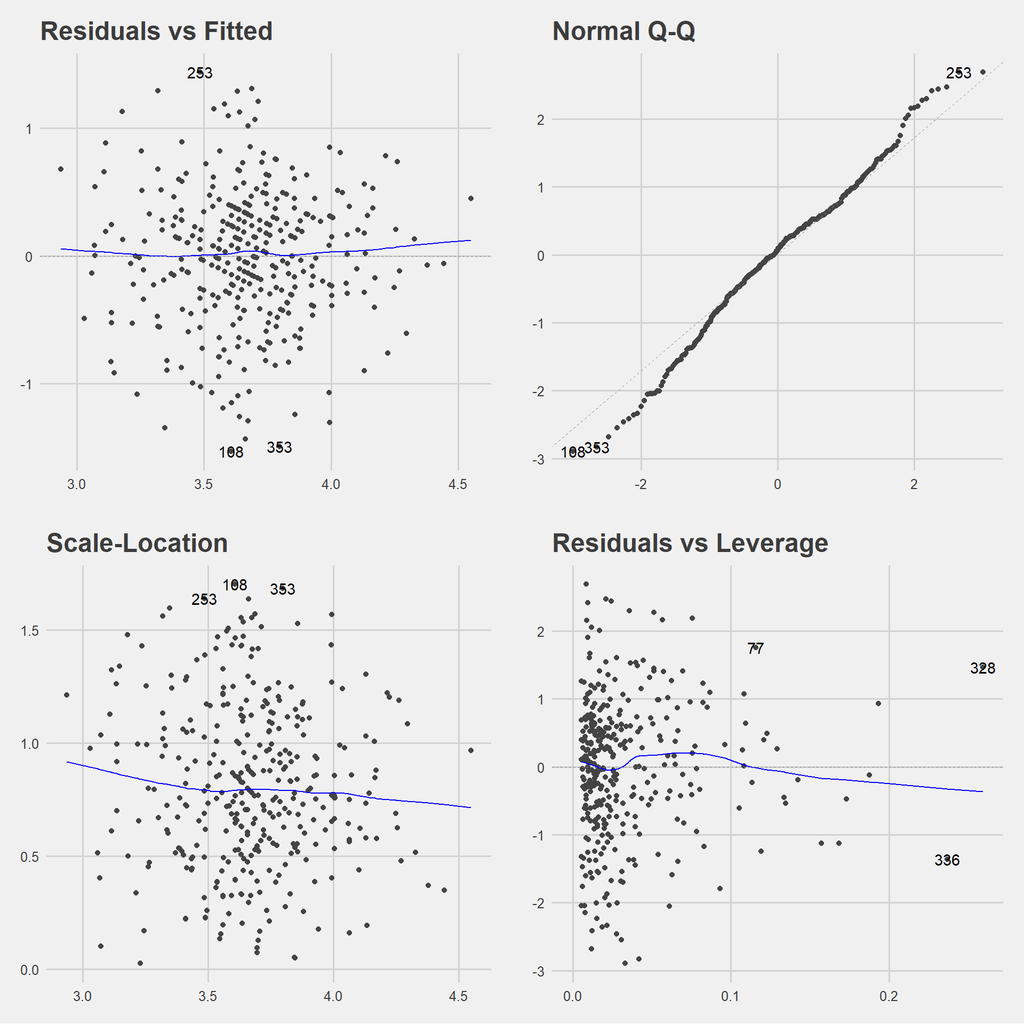

```r
library(ggthemes)
theme_set(theme_fivethirtyeight())

library(ggfortify)
autoplot(gvlma(model2))
```

**Check Multicollinearity for Model 1 & 2**

```r
library(car)
vif(model1);vif(model2)
```

```
## green_attitude      Education         Income         female            Age
##       1.030588       1.283902       1.458383       1.059164       1.439596
##      Ethnicity
##       1.032942
```

```
## there are higher-order terms (interactions) in this model
## consider setting terms = 'marginal' or 'high-order'; see ?vif
```

```
##           green_attitude                      Age                Education
##                 3.249478                 1.465553                 1.291917
##                   female                Ethnicity                   Income
##                 1.068025                 1.041924                 1.498341
##       green_attitude:Age green_attitude:Education    green_attitude:female
##                 1.396452                 1.402606                 3.275639
## green_attitude:Ethnicity    green_attitude:Income
##                 1.101704                 1.483364
```

## **Model 2 Result using `kable` in `R Markdown`**

```r
kable(tidy(model2))%>%
  kable_paper("striped", full_width = T, fixed_thead = T) %>%
  column_spec(c(1, 5), bold = T) %>%
  row_spec(0, bold = T,color = "Black",background = "#D3D3D3") %>%
  row_spec(c(2, 4, 6, 8, 10), color = "Black", background = "#E6E6FA")
```

| term | estimate | std.error | statistic | p.value |
| --- | --- | --- | --- | --- |
| (Intercept) | 3.6522514 | 0.0523947 | 69.7065717 | 0.0000000 |
| green_attitude | 0.3790344 | 0.0914043 | 4.1467882 | 0.0000420 |
| Age | 0.0871850 | 0.0364742 | 2.3903172 | 0.0173430 |
| Education | 0.0245275 | 0.0319896 | 0.7667320 | 0.4437393 |
| female | 0.0331399 | 0.0627189 | 0.5283874 | 0.5975533 |
| Ethnicity | 0.0368866 | 0.0499389 | 0.7386341 | 0.4606065 |
| Income | 0.0009348 | 0.0302750 | 0.0308768 | 0.9753847 |
| green_attitude:Age | 0.0300990 | 0.0591068 | 0.5092305 | 0.6109001 |
| green_attitude:Education | 0.0088026 | 0.0580653 | 0.1515988 | 0.8795876 |
| green_attitude:female | 0.0573521 | 0.1141385 | 0.5024782 | 0.6156358 |
| green_attitude:Ethnicity | 0.2175170 | 0.1032035 | 2.1076509 | 0.0357464 |
| green_attitude:Income | -0.1257890 | 0.0523945 | -2.4008051 | 0.0168616 |

```r
kable(glance(model2))%>%
  kable_paper("striped", full_width = T, font_size = 12) %>%
  column_spec(c(2, 4, 6, 8, 10,12), bold = T, color = "white", background = "#ff6347")
```

| r.squared | adj.r.squared | sigma | statistic | p.value | df | logLik | AIC | BIC | deviance | df.residual | nobs |
| --- | --- | --- | --- | --- | --- | --- | --- | --- | --- | --- | --- |
| 0.1915306 | 0.1670316 | 0.5378723 | 7.817873 | 0 | 11 | -293.4536 | 612.9071 | 663.9572 | 105.0183 | 363 | 375 |

The regression analysis result shows that appears that the relationships between income and green attitude affect the green behaviour.

## Visualize for (Model 2)

*Green Attitude x Income*

```r
library(modelr)
Centered_data_m1 %>% summarise(sd(Income ))
```

```
##   sd(Income)
## 1   1.124512
```

The data collection for gender was not equally distributed, therefore the most frequent gender female that denotes as (“1”) was selected for the analysis.

```r
grid_group3_model2 <- Centered_data_m1 %>%
  data_grid(green_attitude, Income = c(-1.13, 0.00, 1.13),
            female = 1, Age = 0, Education = 0,Ethnicity = 0) %>%
  add_predictions(model2) %>%
  rename(predicted_green_behaviour = pred)

grid_group3_model2
```

```
## # A tibble: 42 x 7
##    green_attitude Income female   Age Education Ethnicity predicted_green_behav~
##             <dbl>  <dbl>  <dbl> <dbl>     <dbl>     <dbl>                  <dbl>
##  1         -1.59   -1.13      1     0         0         0                   2.77
##  2         -1.59    0         1     0         0         0                   2.99
##  3         -1.59    1.13      1     0         0         0                   3.22
##  4         -1.39   -1.13      1     0         0         0                   2.88
##  5         -1.39    0         1     0         0         0                   3.08
##  6         -1.39    1.13      1     0         0         0                   3.28
##  7         -1.19   -1.13      1     0         0         0                   3.00
##  8         -1.19    0         1     0         0         0                   3.17
##  9         -1.19    1.13      1     0         0         0                   3.34
## 10         -0.986  -1.13      1     0         0         0                   3.11
## # ... with 32 more rows
```

## Undo the mean centering for (`green attitude`) variable .

```r
grid <- grid_group3_model2 %>%
  mutate(green_attitude= green_attitude + mean(green_data$green_attitude), Income = factor(as.double(factor(Income))))

grid
```

```
## # A tibble: 42 x 7
##    green_attitude Income female   Age Education Ethnicity predicted_green_behav~
##             <dbl> <fct>   <dbl> <dbl>     <dbl>     <dbl>                  <dbl>
##  1            2.4 1           1     0         0         0                   2.77
##  2            2.4 2           1     0         0         0                   2.99
##  3            2.4 3           1     0         0         0                   3.22
##  4            2.6 1           1     0         0         0                   2.88
##  5            2.6 2           1     0         0         0                   3.08
##  6            2.6 3           1     0         0         0                   3.28
##  7            2.8 1           1     0         0         0                   3.00
##  8            2.8 2           1     0         0         0                   3.17
##  9            2.8 3           1     0         0         0                   3.34
## 10            3   1           1     0         0         0                   3.11
## # ... with 32 more rows
```

## ggplot on predicted_green_behaviour, Income is a catergoical variable

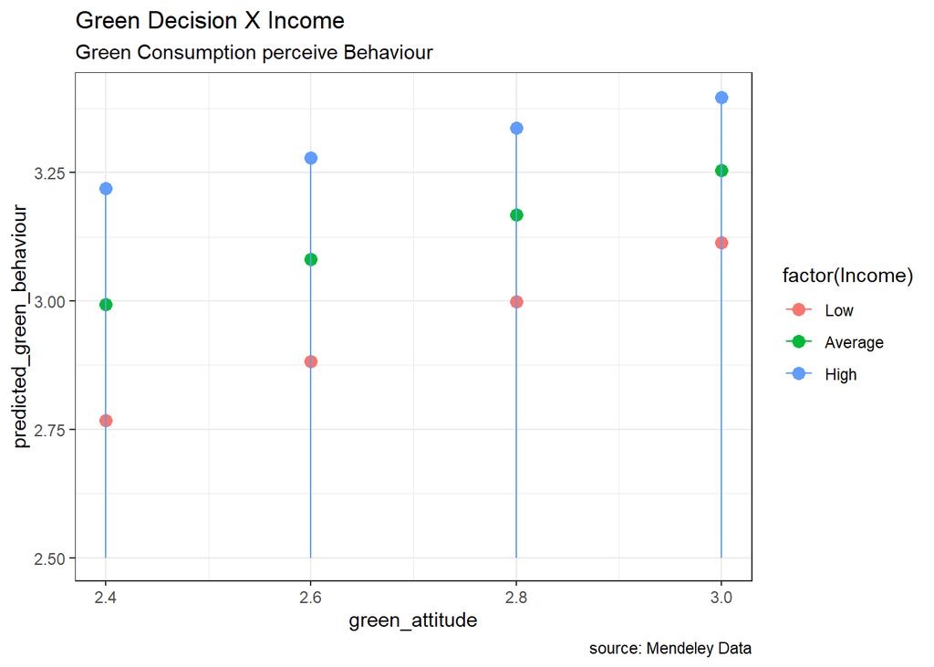

```r
ggplot(grid, aes(x = green_attitude , y = predicted_green_behaviour, color = factor(Income))) +
  geom_point(size=3) +
  scale_color_discrete(breaks = c(1,2,3), label=c("Low", "Average","High")) +
  geom_segment(aes(x=green_attitude,
                   xend=green_attitude,
                   y=2.5,
                   yend=predicted_green_behaviour)) +
  coord_cartesian(ylim = c(2.5, 3.4),
                  xlim = c(2.4, 3.0)) +
  theme_bw() +
  labs(title="Green Decision X Income",
       subtitle="Green Consumption perceive Behaviour ",
       caption="source: Mendeley Data")
```

```r
pacman::p_load(jtools, huxtable, ggstance, interactions,gridExtra,sandwich)
```

## Summarise Model 1 & 2

```r
export_summs(model1, model2,
             error_format = "(t = {statistic}, p = {p.value})",
             align = "right",
             model.names = c("Main Effects Only", "with Interactions"),
             digits = 3)
```

|  | Main Effects Only | with Interactions |
| --- | --- | --- |
| (Intercept) | 3.655 *** | 3.652 *** |
|  | (t = 69.971, p = 0.000) | (t = 69.707, p = 0.000) |
| green_attitude | 0.411 *** | 0.379 *** |
|  | (t = 7.923, p = 0.000) | (t = 4.147, p = 0.000) |
| Education | 0.028 | 0.025 |
|  | (t = 0.858, p = 0.391) | (t = 0.767, p = 0.444) |
| Income | -0.011 | 0.001 |
|  | (t = -0.363, p = 0.717) | (t = 0.031, p = 0.975) |
| female | 0.023 | 0.033 |
|  | (t = 0.373, p = 0.709) | (t = 0.528, p = 0.598) |
| Age | 0.085 * | 0.087 * |
|  | (t = 2.344, p = 0.020) | (t = 2.390, p = 0.017) |
| Ethnicity | 0.049 | 0.037 |
|  | (t = 0.977, p = 0.329) | (t = 0.739, p = 0.461) |
| green_attitude:Age |  | 0.030 |
|  |  | (t = 0.509, p = 0.611) |
| green_attitude:Education |  | 0.009 |
|  |  | (t = 0.152, p = 0.880) |
| green_attitude:female |  | 0.057 |
|  |  | (t = 0.502, p = 0.616) |
| green_attitude:Ethnicity |  | 0.218 * |
|  |  | (t = 2.108, p = 0.036) |
| green_attitude:Income |  | -0.126 * |
|  |  | (t = -2.401, p = 0.017) |
| N | 375 | 375 |
| R2 | 0.169 | 0.192 |
| *** p < 0.001; ** p < 0.01; * p < 0.05. |  |  |

**Undid the mean centering for Model 2**

```r
model2_WO_center <-  green_data %>%
  lm(formula = green_behaviour ~ green_attitude*( Age + Education + female + Ethnicity + Income),
     data = .)
```

```r
summ(model2,
     digits = 3)
```

| Observations | 375 |
| --- | --- |
| Dependent variable | green_behaviour |
| Type | OLS linear regression |

| F(11,363) | 7.818 |
| --- | --- |
| R² | 0.192 |
| Adj. R² | 0.167 |

|  | Est. | S.E. | t val. | p |
| --- | --- | --- | --- | --- |
| (Intercept) | 3.652 | 0.052 | 69.707 | 0.000 |
| green_attitude | 0.379 | 0.091 | 4.147 | 0.000 |
| Age | 0.087 | 0.036 | 2.390 | 0.017 |
| Education | 0.025 | 0.032 | 0.767 | 0.444 |
| female | 0.033 | 0.063 | 0.528 | 0.598 |
| Ethnicity | 0.037 | 0.050 | 0.739 | 0.461 |
| Income | 0.001 | 0.030 | 0.031 | 0.975 |
| green_attitude:Age | 0.030 | 0.059 | 0.509 | 0.611 |
| green_attitude:Education | 0.009 | 0.058 | 0.152 | 0.880 |
| green_attitude:female | 0.057 | 0.114 | 0.502 | 0.616 |
| green_attitude:Ethnicity | 0.218 | 0.103 | 2.108 | 0.036 |
| green_attitude:Income | -0.126 | 0.052 | -2.401 | 0.017 |

Standard errors: OLS

```r
summ(model2_WO_center,
     center = T)
```

| Observations | 375 |
| --- | --- |
| Dependent variable | green_behaviour |
| Type | OLS linear regression |

| F(11,363) | 7.82 |
| --- | --- |
| R² | 0.19 |
| Adj. R² | 0.17 |

|  | Est. | S.E. | t val. | p |
| --- | --- | --- | --- | --- |
| (Intercept) | 3.65 | 0.05 | 69.71 | 0.00 |
| green_attitude | 0.38 | 0.09 | 4.15 | 0.00 |
| Age | 0.09 | 0.04 | 2.39 | 0.02 |
| Education | 0.02 | 0.03 | 0.77 | 0.44 |
| female | 0.03 | 0.06 | 0.53 | 0.60 |
| Ethnicity | 0.04 | 0.05 | 0.74 | 0.46 |
| Income | 0.00 | 0.03 | 0.03 | 0.98 |
| green_attitude:Age | 0.03 | 0.06 | 0.51 | 0.61 |
| green_attitude:Education | 0.01 | 0.06 | 0.15 | 0.88 |
| green_attitude:female | 0.06 | 0.11 | 0.50 | 0.62 |
| green_attitude:Ethnicity | 0.22 | 0.10 | 2.11 | 0.04 |
| green_attitude:Income | -0.13 | 0.05 | -2.40 | 0.02 |

Standard errors: OLS; Continuous predictors are mean-centered.

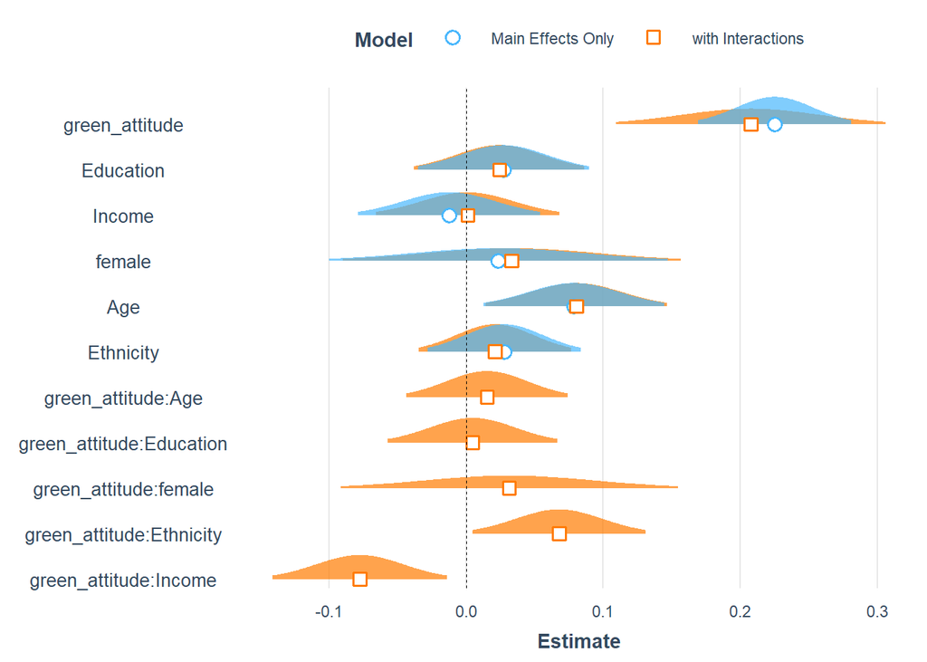

```r
plot_summs(model1, model2,
           scale = T,
           plot.distributions = T,
           model.names = c("Main Effects Only", "with Interactions")) +
  theme(legend.position = "top")
```

Step 1: Plot interaction using interact_plot(interval = T) —-

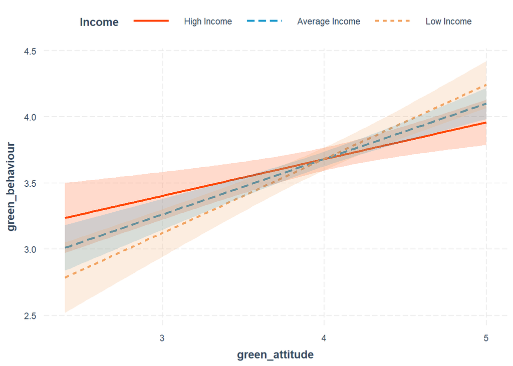

```r
interact_plot(model = model2_WO_center, # plug-in your model
              pred = green_attitude, # pred = predictor = X1 = Explanatory
              modx = Income, # modx = moderator = X2
              modx.labels = c("Low Income",
                              "Average Income",
                              "High Income"),
              legend.main = "Income",
              colors = c("sandybrown",
                         "deepskyblue3",
                         "orangered1"),
              interval = T # display confidence intervals
              ) +
  theme(legend.position = "top")
```

Step 2 : Run simple slopes analysis

```r
sim_slopes(model2_WO_center,
           pred = green_attitude,
           modx = Income,
           johnson_neyman = F)
```

```
## SIMPLE SLOPES ANALYSIS
##
## Slope of green_attitude when Income = 1.022154 (- 1 SD):
##
##   Est.   S.E.   t val.      p
## ------ ------ -------- ------
##   0.56   0.08     7.05   0.00
##
## Slope of green_attitude when Income = 2.146667 (Mean):
##
##   Est.   S.E.   t val.      p
## ------ ------ -------- ------
##   0.42   0.05     8.05   0.00
##
## Slope of green_attitude when Income = 3.271179 (+ 1 SD):
##
##   Est.   S.E.   t val.      p
## ------ ------ -------- ------
##   0.28   0.08     3.57   0.00
```

Step 3: Spotlight analysis

```r
sim_slopes(model2_WO_center,
           pred = Income,
           modx = green_attitude,
           johnson_neyman = T)
```

```
## JOHNSON-NEYMAN INTERVAL
##
## When green_attitude is OUTSIDE the interval [3.07, 4.73], the slope of
## Income is p < .05.
##
## Note: The range of observed values of green_attitude is [2.40, 5.00]
##
## SIMPLE SLOPES ANALYSIS
##
## Slope of Income when green_attitude = 3.437091 (- 1 SD):
##
##   Est.   S.E.   t val.      p
## ------ ------ -------- ------
##   0.07   0.04     1.60   0.11
##
## Slope of Income when green_attitude = 3.985600 (Mean):
##
##   Est.   S.E.   t val.      p
## ------ ------ -------- ------
##   0.00   0.03     0.03   0.98
##
## Slope of Income when green_attitude = 4.534109 (+ 1 SD):
##
##    Est.   S.E.   t val.      p
## ------- ------ -------- ------
##   -0.07   0.04    -1.71   0.09
```

Step 4: Run interaction_plot() again by adding benchmark for regions of significance

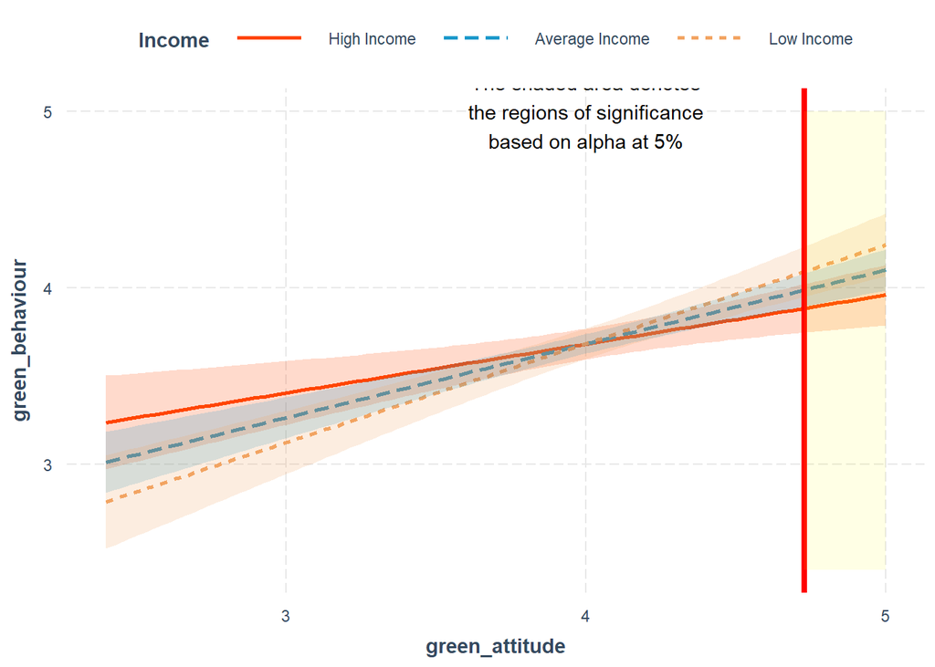

```r
interact_plot(model = model2_WO_center, # plug-in your model
              pred = green_attitude, # pred = predictor = X1 = Explanatory
              modx = Income, # modx = moderator = X2
              modx.labels = c("Low Income",
                              "Average Income",
                              "High Income"),
              legend.main = "Income",
              colors = c("sandybrown",
                         "deepskyblue3",
                         "orangered1"),
              interval = T # display confidence intervals
              ) +
  theme(legend.position = "top") +
  geom_vline(xintercept = 4.73,
             color = "red",
             size = 1.5) +
  annotate("rect",
           fill = "yellow",
           xmin = 4.73,
           xmax = 5.0,
           ymin = 2.4,
           ymax = 5.0,
           alpha = 0.10) +
  annotate("text",
           x = 4.0,
           y = 5.0,
           label = "The shaded area denotes\nthe regions of significance\nbased on alpha at 5%")
```

Step 5: Finalize the figure by adding necessary information

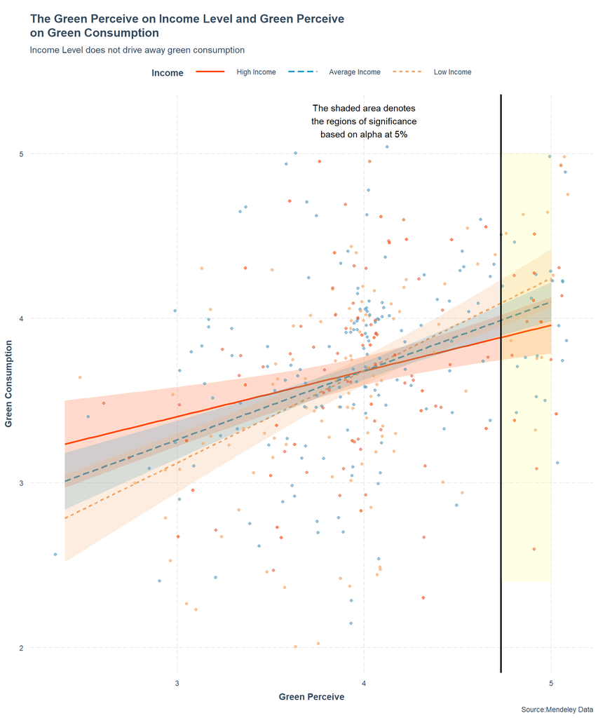

```r
interact_plot(model = model2_WO_center,
              pred = green_attitude,
              modx = Income,
              modx.labels = c("Low Income",
                              "Average Income",
                              "High Income"),
              legend.main = "Income",
              colors = c("sandybrown",
                         "deepskyblue3",
                         "orangered1"),
              interval = T ,# display confidence intervals
              plot.points = T, # reveal your data points
              jitter = 0.1) +
  theme(legend.position = "top") +
  labs(y = "Green Consumption",
       x = "Green Perceive",
       title = "The Green Perceive on Income Level and Green Perceive\non Green Consumption",
       subtitle = "Income Level does not drive away green consumption",
       caption = "Source:Mendeley Data") +
  geom_vline(xintercept = 4.73,
             color = "black",
             size = 1.0) +
  annotate("rect",
           fill = "yellow",
           xmin = 4.73,
           xmax = 5.0,
           ymin = 2.4,
           ymax = 5.0,
           alpha = 0.10) +
  annotate("text",
           x = 4.0,
           y = 5.2,
           label = "The shaded area denotes\nthe regions of significance\nbased on alpha at 5%")
```

```r
  theme_fivethirtyeight() +
  theme(legend.position = "top",
        axis.title = element_text(),
        text = element_text(family = "Courier")
        )
```

[output not shown]

[output cut: 375 more lines]

[output not shown]

## Interpretation for Model 2 Green Attitude X Income

Green attitude and income level is based on observational study,leading to correlation causation in limitations and future directions.

**Model 3 & 4 : Green Seeking X Gender**

```r
Centered_data_m2 <- green_data %>%
    mutate_at(vars(-c(green_behaviour,female)
    ),
    ~(. - mean(., na.rm = T)
    )
    )
```

```r
model3 <- Centered_data_m2 %>%
    lm(formula =    green_behaviour ~ green_seeking + Age + Ethnicity + Income + Education + female + green_concern,
       data = .)
```

```r
model4 <- Centered_data_m2 %>%
    lm(formula = green_behaviour ~ green_seeking *(Ethnicity + Income + Education  + Age + female)+ green_concern,
       data = .)
```

```r
gvlma(model4)
```

```
##
## Call:
## lm(formula = green_behaviour ~ green_seeking * (Ethnicity + Income +
##     Education + Age + female) + green_concern, data = .)
##
## Coefficients:
##             (Intercept)            green_seeking                Ethnicity
##                3.669632                 0.557914                 0.107395
##                  Income                Education                      Age
##               -0.006267                 0.034215                 0.049272
##                  female            green_concern  green_seeking:Ethnicity
##                0.008959                 0.234828                 0.021683
##    green_seeking:Income  green_seeking:Education        green_seeking:Age
##               -0.052461                -0.045064                -0.017797
##    green_seeking:female
##               -0.151209
##
##
## ASSESSMENT OF THE LINEAR MODEL ASSUMPTIONS
## USING THE GLOBAL TEST ON 4 DEGREES-OF-FREEDOM:
## Level of Significance =  0.05
##
## Call:
##  gvlma(x = model4)
##
##                     Value p-value                Decision
## Global Stat        2.3724  0.6676 Assumptions acceptable.
## Skewness           0.2168  0.6415 Assumptions acceptable.
## Kurtosis           0.4177  0.5181 Assumptions acceptable.
## Link Function      1.4190  0.2336 Assumptions acceptable.
## Heteroscedasticity 0.3189  0.5723 Assumptions acceptable.
```

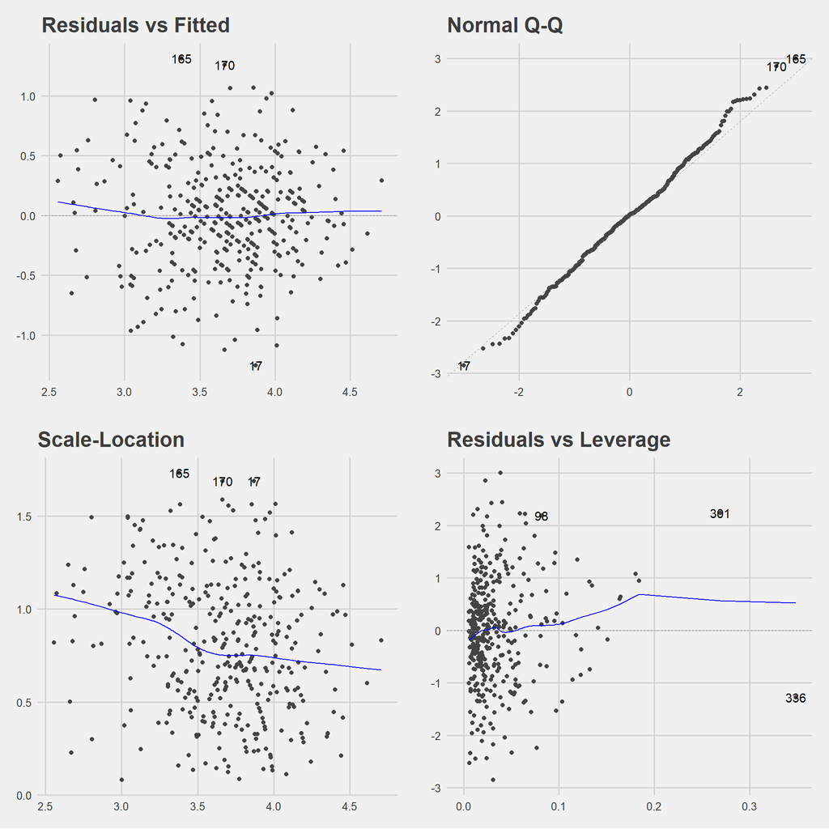

```r
library(ggthemes)
theme_set(theme_fivethirtyeight())


library(ggfortify)
autoplot(gvlma(model4))
```

## Analysis of Variance (ANOVA) for Model 3 & 4

```r
anova(model3,model4)
```

| Res.Df | RSS | Df | Sum of Sq | F | Pr(>F) |
| --- | --- | --- | --- | --- | --- |
| 367 | 74.5 |  |  |  |  |
| 362 | 72.3 | 5 | 2.16 | 2.16 | 0.0578 |

## **Check Multicollinearity for Model 3 & 4**

```r
vif(model3);vif(model4)
```

```
## green_seeking           Age     Ethnicity        Income     Education
##      1.109350      1.448675      1.042453      1.457345      1.280457
##        female green_concern
##      1.057972      1.116852
```

```
## there are higher-order terms (interactions) in this model
## consider setting terms = 'marginal' or 'high-order'; see ?vif
```

```
##           green_seeking               Ethnicity                  Income
##                4.061048                1.064462                1.479583
##               Education                     Age                  female
##                1.304022                1.458574                1.079932
##           green_concern green_seeking:Ethnicity    green_seeking:Income
##                1.137190                1.160915                1.537634
## green_seeking:Education       green_seeking:Age    green_seeking:female
##                1.325998                1.424491                4.002844
```

## Applying Kable for Model 4

```r
kable(tidy(model4))%>%
  kable_paper("striped", full_width = T, fixed_thead = T) %>%
  column_spec(c(1, 5), bold = T) %>%
  row_spec(0, bold = T,color = "Black",background = "#D3D3D3") %>%
  row_spec(c(2, 4, 6, 8, 10), color = "Black", background = "#E6E6FA")
```

| term | estimate | std.error | statistic | p.value |
| --- | --- | --- | --- | --- |
| (Intercept) | 3.6696318 | 0.0435378 | 84.2861024 | 0.0000000 |
| green_seeking | 0.5579143 | 0.0635700 | 8.7763820 | 0.0000000 |
| Ethnicity | 0.1073945 | 0.0419384 | 2.5607672 | 0.0108490 |
| Income | -0.0062668 | 0.0249962 | -0.2507079 | 0.8021822 |
| Education | 0.0342151 | 0.0267030 | 1.2813212 | 0.2009010 |
| Age | 0.0492724 | 0.0302326 | 1.6297759 | 0.1040187 |
| female | 0.0089591 | 0.0524001 | 0.1709750 | 0.8643389 |
| green_concern | 0.2348276 | 0.0482105 | 4.8708851 | 0.0000017 |
| green_seeking:Ethnicity | 0.0216831 | 0.0571624 | 0.3793242 | 0.7046695 |
| green_seeking:Income | -0.0524606 | 0.0314192 | -1.6696999 | 0.0958432 |
| green_seeking:Education | -0.0450645 | 0.0381739 | -1.1805048 | 0.2385746 |
| green_seeking:Age | -0.0177971 | 0.0403776 | -0.4407663 | 0.6596453 |
| green_seeking:female | -0.1512089 | 0.0737899 | -2.0491806 | 0.0411648 |

```r
kable(glance(model4))%>%
  kable_paper("striped", full_width = T, font_size = 12) %>%
  column_spec(c(2, 4, 6, 8, 10,12), bold = T, color = "white", background = "#ff6347")
```

| r.squared | adj.r.squared | sigma | statistic | p.value | df | logLik | AIC | BIC | deviance | df.residual | nobs |
| --- | --- | --- | --- | --- | --- | --- | --- | --- | --- | --- | --- |
| 0.4434334 | 0.4249837 | 0.4468945 | 24.03469 | 0 | 12 | -223.4493 | 474.8986 | 529.8756 | 72.29671 | 362 | 375 |

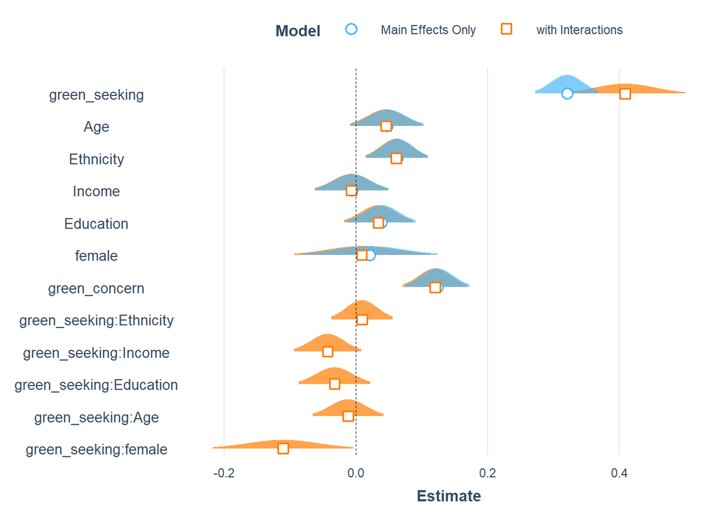

```r
plot_summs(model3, model4,
           scale = T,
           plot.distributions = T,
           model.names = c("Main Effects Only", "with Interactions")) +
  theme(legend.position = "top")
```

## Summarise Model 3 & Model 4

```r
export_summs(model3,
             model4,
             model.names = c ("Main Effeects only",
                              "with Interaction"),
             error_format = "CIs = [{conf.low} , {conf.high}]",
             dights = 3
             )
```

|  | Main Effeects only | with Interaction |
| --- | --- | --- |
| (Intercept) | 3.66 *** | 3.67 *** |
|  | CIs = [3.57 , 3.74] | CIs = [3.58 , 3.76] |
| green_seeking | 0.44 *** | 0.56 *** |
|  | CIs = [0.37 , 0.50] | CIs = [0.43 , 0.68] |
| Age | 0.05 | 0.05 |
|  | CIs = [-0.01 , 0.11] | CIs = [-0.01 , 0.11] |
| Ethnicity | 0.11 ** | 0.11 * |
|  | CIs = [0.03 , 0.19] | CIs = [0.02 , 0.19] |
| Income | -0.01 | -0.01 |
|  | CIs = [-0.05 , 0.04] | CIs = [-0.06 , 0.04] |
| Education | 0.04 | 0.03 |
|  | CIs = [-0.01 , 0.09] | CIs = [-0.02 , 0.09] |
| female | 0.02 | 0.01 |
|  | CIs = [-0.08 , 0.12] | CIs = [-0.09 , 0.11] |
| green_concern | 0.24 *** | 0.23 *** |
|  | CIs = [0.15 , 0.34] | CIs = [0.14 , 0.33] |
| green_seeking:Ethnicity |  | 0.02 |
|  |  | CIs = [-0.09 , 0.13] |
| green_seeking:Income |  | -0.05 |
|  |  | CIs = [-0.11 , 0.01] |
| green_seeking:Education |  | -0.05 |
|  |  | CIs = [-0.12 , 0.03] |
| green_seeking:Age |  | -0.02 |
|  |  | CIs = [-0.10 , 0.06] |
| green_seeking:female |  | -0.15 * |
|  |  | CIs = [-0.30 , -0.01] |
| N | 375 | 375 |
| R2 | 0.43 | 0.44 |
| *** p < 0.001; ** p < 0.01; * p < 0.05. |  |  |

## Undo the mean centering for(green_seeking)variable .

```r
predicted_Y_value <- Centered_data_m2 %>%
  modelr::data_grid(green_seeking,
                    female,
                    Age = 0 ,
                    Education  = 0,
                    Income = 0,
                    Ethnicity = 0 ,
                    green_concern = 0,
                    ) %>%
  add_predictions(model4) %>%
  rename(predicted_green_behaviour = pred)
```

```r
predicted_Y_value %>%
  print(n = nrow(.)
        )
```

```
## # A tibble: 64 x 8
##    green_seeking female   Age Education Income Ethnicity green_concern
##            <dbl>  <dbl> <dbl>     <dbl>  <dbl>     <dbl>         <dbl>
##  1       -2.20        0     0         0      0         0             0
##  2       -2.20        1     0         0      0         0             0
##  3       -2.08        0     0         0      0         0             0
##  4       -2.08        1     0         0      0         0             0
##  5       -1.95        0     0         0      0         0             0
##  6       -1.95        1     0         0      0         0             0
##  7       -1.83        0     0         0      0         0             0
##  8       -1.83        1     0         0      0         0             0
##  9       -1.70        0     0         0      0         0             0
## 10       -1.70        1     0         0      0         0             0
## 11       -1.58        0     0         0      0         0             0
## 12       -1.58        1     0         0      0         0             0
```

[output cut: 53 more lines]

```r
predicted_Y_value <- predicted_Y_value %>%
  mutate(green_seeking = green_seeking + mean(green_data$green_seeking)
         )
```

```r
predicted_Y_value %>%
  print(n = nrow(.)
        )
```

```
## # A tibble: 64 x 8
##    green_seeking female   Age Education Income Ethnicity green_concern
##            <dbl>  <dbl> <dbl>     <dbl>  <dbl>     <dbl>         <dbl>
##  1          1.12      0     0         0      0         0             0
##  2          1.12      1     0         0      0         0             0
##  3          1.25      0     0         0      0         0             0
##  4          1.25      1     0         0      0         0             0
##  5          1.38      0     0         0      0         0             0
##  6          1.38      1     0         0      0         0             0
##  7          1.5       0     0         0      0         0             0
##  8          1.5       1     0         0      0         0             0
##  9          1.62      0     0         0      0         0             0
## 10          1.62      1     0         0      0         0             0
## 11          1.75      0     0         0      0         0             0
## 12          1.75      1     0         0      0         0             0
```

[output cut: 53 more lines]

## Predicted Green Behaviour X Gender

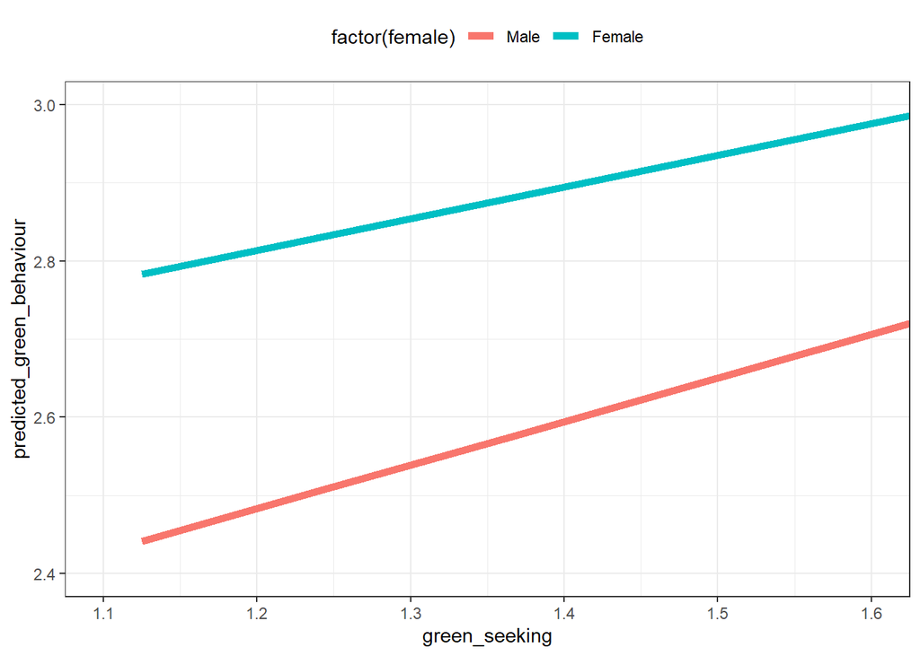

```r
estimated <- predicted_Y_value %>%
  ggplot(aes(x = green_seeking,
             y = predicted_green_behaviour,
             color = factor(female)
             )
         ) +
  geom_line(size = 2) +
  scale_color_discrete(breaks = c(0, 1),
                       label = c("Male",
                                 "Female")
                       ) +
  coord_cartesian(ylim = c(2.4, 3.0),
                  xlim = c(1.1, 1.6)
                  ) +
  theme_bw() +
  theme(legend.position = "top")

estimated
```

## Estimated_vs_observed Green Seeking X Gender

```r
estimated_vs_observed <- ggplot(data = green_data,
                                aes(x = green_seeking,
                                    y = green_behaviour)
                                ) +
  geom_point(aes(color =factor(female)
                ),
             alpha = 0.25) +
    geom_line(data = predicted_Y_value,
              aes(y = predicted_green_behaviour,
                  color = factor(female)
                  ),
              size = 1.5
              ) +
  facet_wrap(. ~ factor(female),
             labeller = as_labeller(c("0" = "MALE",
                                      "1" = "FEMALE")
                                    )
              ) +
  coord_cartesian(ylim = c (2.4, 3.0),
                  xlim = c (1.1, 1.6)
                  ) +
  theme_bw() +
  theme(legend.position = "none")
```

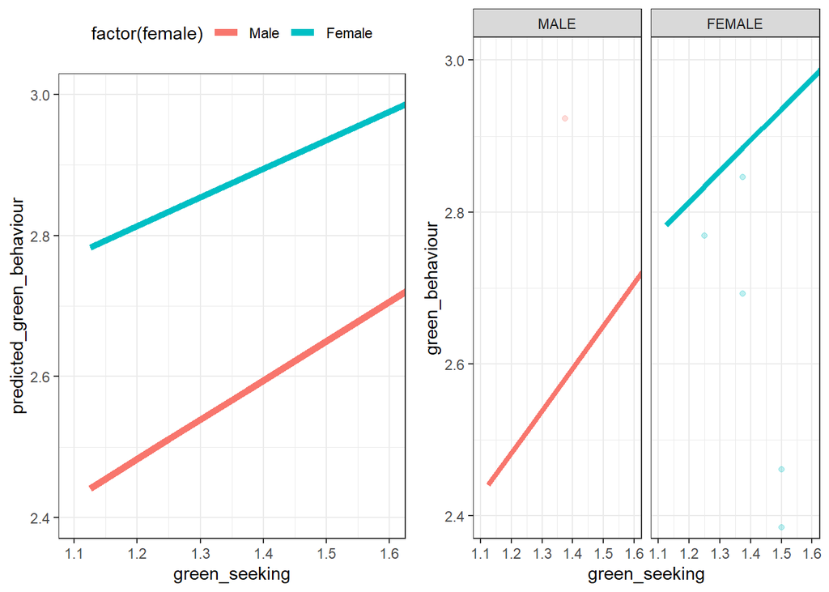

```r
grid.arrange(estimated, estimated_vs_observed, ncol = 2)
```

## Un-do Mean Centering for Model 4

```r
model4_WO_center <- green_data %>%
    lm(formula = green_behaviour ~ green_seeking *(Ethnicity + Income + Education  + Age + female)+ green_concern,
       data = .)
```